# Lab 7

[Team Mack and Jill]

[11/16/2017]

**Author:** [Mack]

**Discussants:** [Jill]

**Load data:**

```r
load(url("http://foxweb.marist.edu/users/duy.nguyen2/atheism.RData"))
head(atheism)
```

```
##   nationality    response year
## 1 Afghanistan non-atheist 2012
## 2 Afghanistan non-atheist 2012
## 3 Afghanistan non-atheist 2012
## 4 Afghanistan non-atheist 2012
## 5 Afghanistan non-atheist 2012
## 6 Afghanistan non-atheist 2012
```

#### 1:

We think that the findings are sample statistics, because only 50,000 people were surveyed globally, yet the population of the world is around 7.6 billion. #### 2: Each row of table 6 corresponds to a different countries’ polled religious beliefs, displaying the percentages based on the sample of religious, non religious, and atheists. Each row of atheism corresponds to an individual answer of the poll, giving that person’s country, religious viwes, and the year in which they were surveyed. #### 3: Yes, the proportion matches up with Tabl6 at 5%.

```r
us12 <- subset(atheism, nationality == "United States" & year == "2012")
head(us12)
```

```
##         nationality    response year
## 49926 United States non-atheist 2012
## 49927 United States non-atheist 2012
## 49928 United States non-atheist 2012
## 49929 United States non-atheist 2012
## 49930 United States non-atheist 2012
## 49931 United States non-atheist 2012
```

```r
summary(us12)
```

```
##         nationality          response        year
##  United States:1002   atheist    : 50   Min.   :2012
##  Afghanistan  :   0   non-atheist:952   1st Qu.:2012
##  Argentina    :   0                     Median :2012
##  Armenia      :   0                     Mean   :2012
##  Australia    :   0                     3rd Qu.:2012
##  Austria      :   0                     Max.   :2012
##  (Other)      :   0
```

```r
proportion=50/(952+50)
proportion
```

```
## [1] 0.0499002
```

#### 4:

The conditions that need to be met for a confidence interval are: the sample is simple and random, the sampling distribution is approximately normal or n>=40, and the population standard deviation is unknown. The sample from us12 is random, n>40, and we do not know the standard deviation.

```r
load(url("http://foxweb.marist.edu/users/duy.nguyen2/inference.RData"))
inference(us12$response, est = "proportion", type = "ci", method = "theoretical", success = "atheist")
```

```
## Single proportion -- success: atheist
## Summary statistics:
```

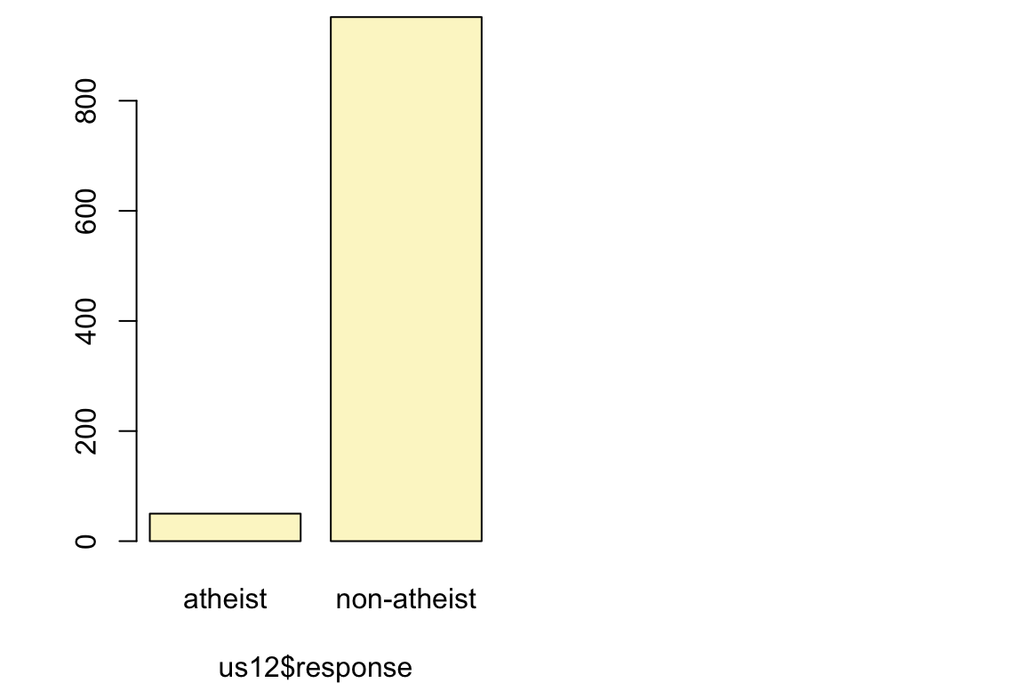

```
## p_hat = 0.0499 ;  n = 1002
## Check conditions: number of successes = 50 ; number of failures = 952
## Standard error = 0.0069
## 95 % Confidence interval = ( 0.0364 , 0.0634 )
```

#### 5:

me <- 2 * sqrt(p * (1 - p)/n)

```r
meUS<- 2 * sqrt(0.0499 * (1 - 0.0499)/1002)
meUS
```

```
## [1] 0.01375723
```

#### 6:

```r
brazil02 <- subset(atheism, nationality == "Brazil" & year == "2012")
inference(brazil02$response, est = "proportion", type = "ci", method = "theoretical", success = "atheist")
```

```
## Single proportion -- success: atheist
## Summary statistics:
```

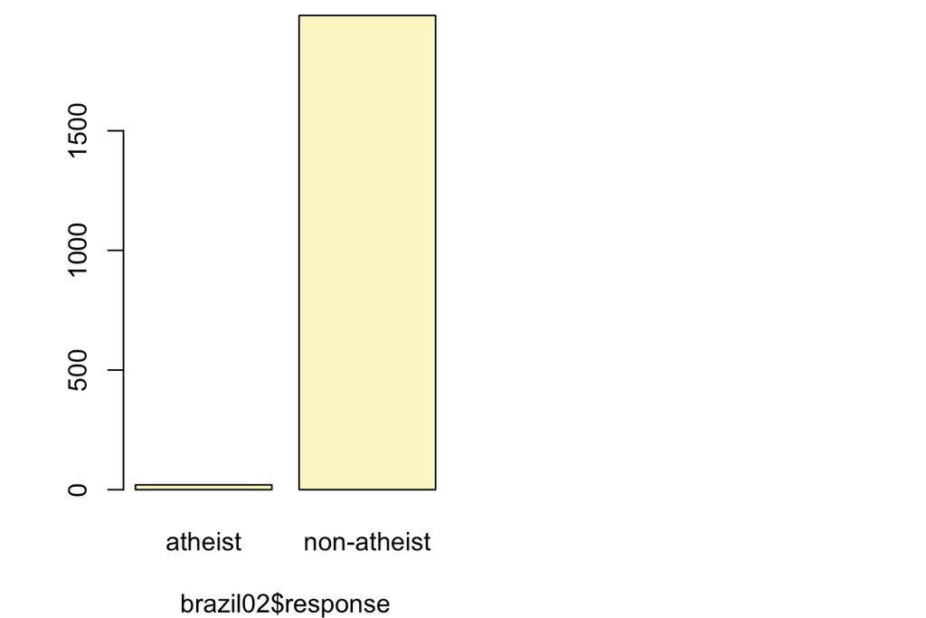

```
## p_hat = 0.01 ;  n = 2002
## Check conditions: number of successes = 20 ; number of failures = 1982
## Standard error = 0.0022
## 95 % Confidence interval = ( 0.0056 , 0.0143 )
```

```r
meB <- 2 * sqrt(0.01 * (1 - 0.01/2002))

france02<-subset(atheism, nationality == "France" & year == "2012")
inference(france02$response, est = "proportion", type = "ci", method = "theoretical", success = "atheist")
```

```
## Single proportion -- success: atheist
## Summary statistics:
```

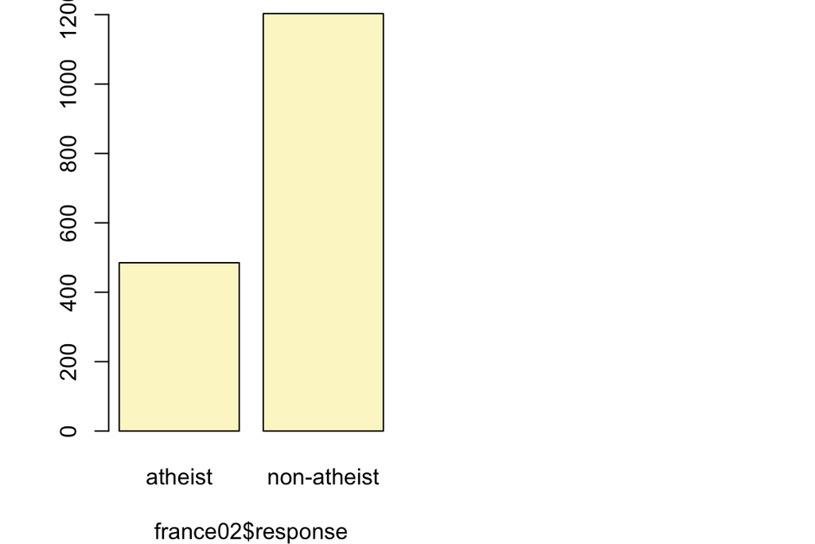

```
## p_hat = 0.2873 ;  n = 1688
## Check conditions: number of successes = 485 ; number of failures = 1203
## Standard error = 0.011
## 95 % Confidence interval = ( 0.2657 , 0.3089 )
```

```r
meF <- 2 * sqrt(0.2873 * (1 - 0.2873)/1688)
```

#### 7:

The closer the population proportion is to .5, the larger it is, while the closer to 1.0 or 0.0, the smaller it is.

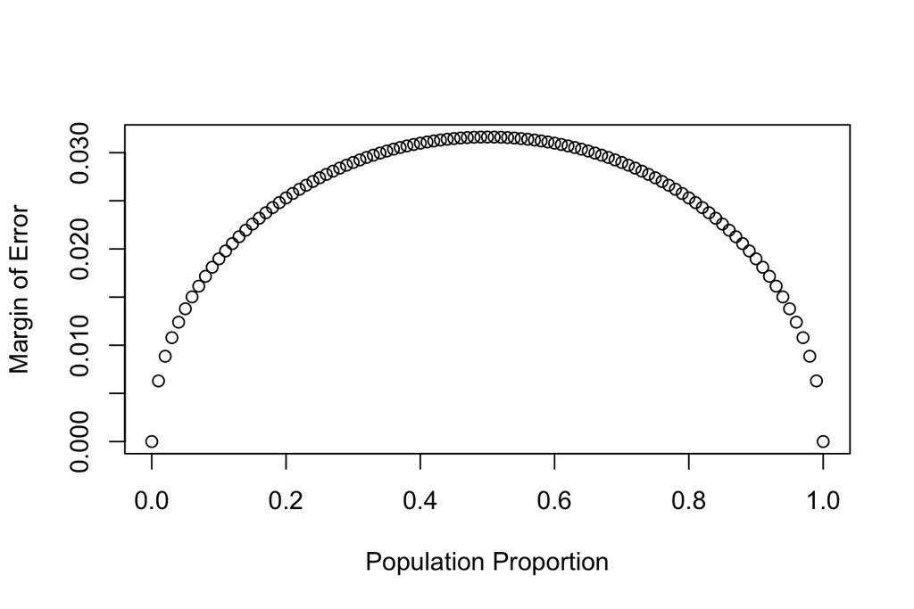

```r
n <- 1000
p <- seq(0, 1, 0.01)
me <- 2 * sqrt(p * (1 - p)/n)
plot(me ~ p, ylab = "Margin of Error", xlab = "Population Proportion")
```

#### 8:

The spread of this graph is fairly normal and bell-shaped. The mean of 0.100 looks to be exactly where the center of the graph is. The histogram is not too spread out, and it seems pretty focused around the mean.

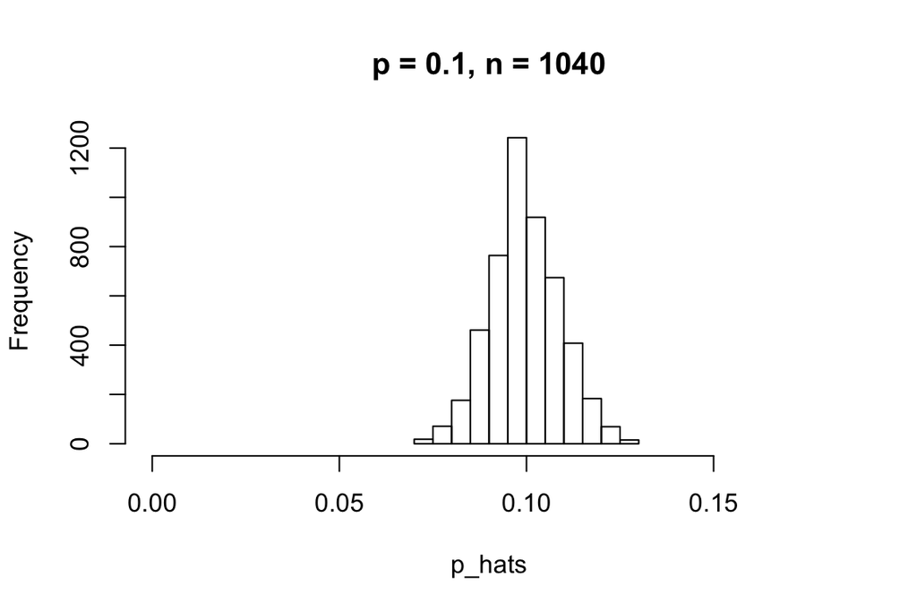

```r
p <- 0.1
n <- 1040
p_hats <- rep(0, 5000)

for(i in 1:5000){
  samp <- sample(c("atheist", "non_atheist"), n, replace = TRUE, prob = c(p, 1-p))
  p_hats[i] <- sum(samp == "atheist")/n
}

hist(p_hats, main = "p = 0.1, n = 1040", xlim = c(0, 0.18))
```

```r
mean(p_hats)
```

```
## [1] 0.09969
```

#### 9:

The shape of the first graph is the most normal of the three, but all three graphs appear to be relatively normal. The second graph has a much smaller spread, and the third graph is somewhere in the middle of the others. N appears to affect the disribution by making the spread much smaller, while p just effects where the mean is. Neither appear to have a huge affect on normality.

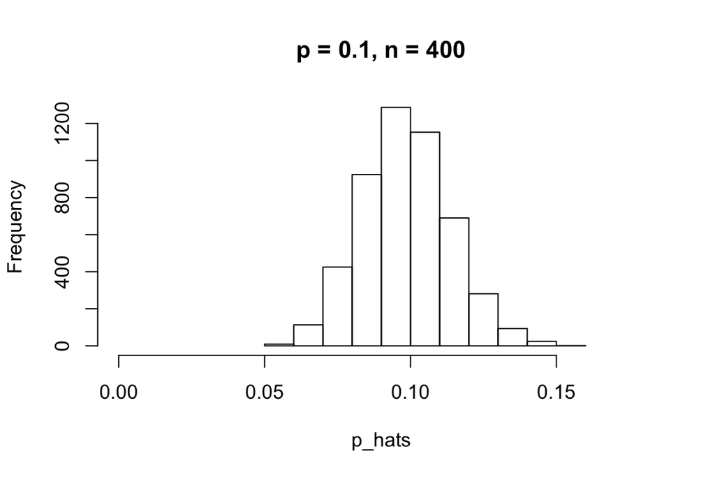

```r
p <- 0.1
n <- 400
p_hats <- rep(0, 5000)

for(i in 1:5000){
  samp <- sample(c("atheist", "non_atheist"), n, replace = TRUE, prob = c(p, 1-p))
  p_hats[i] <- sum(samp == "atheist")/n
}

hist(p_hats, main = "p = 0.1, n = 400", xlim = c(0, 0.18))
```

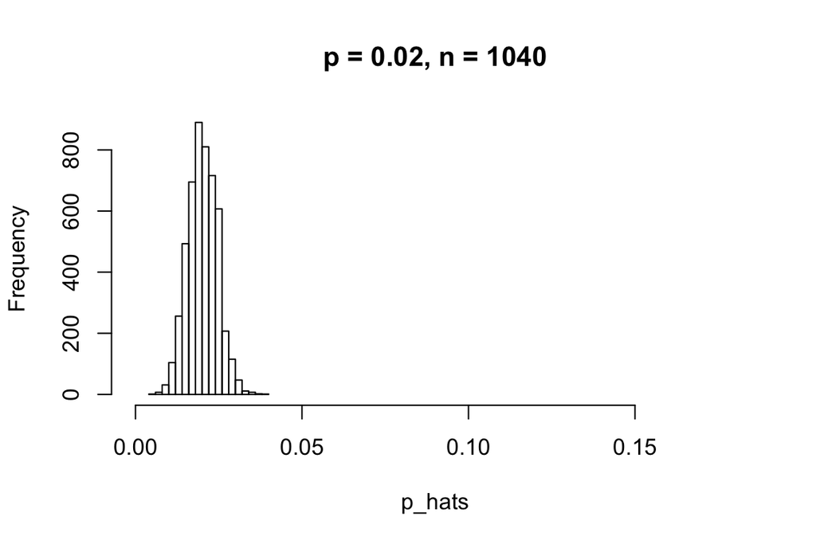

```r
p <- 0.02
n <- 1040
p_hats <- rep(0, 5000)

for(i in 1:5000){
  samp <- sample(c("atheist", "non_atheist"), n, replace = TRUE, prob = c(p, 1-p))
  p_hats[i] <- sum(samp == "atheist")/n
}

hist(p_hats, main = "p = 0.02, n = 1040", xlim = c(0, 0.18))
```

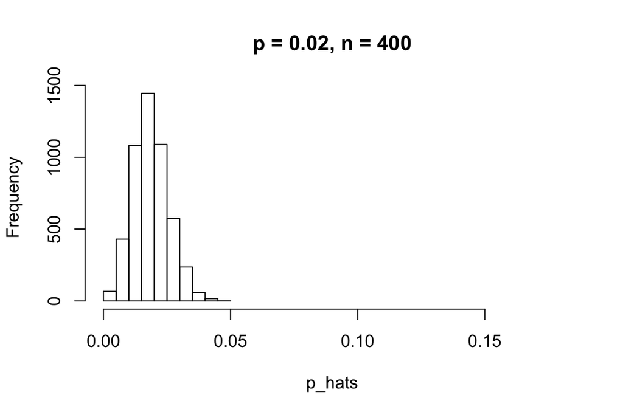

```r
p <- 0.02
n <- 400
p_hats <- rep(0, 5000)

for(i in 1:5000){
  samp <- sample(c("atheist", "non_atheist"), n, replace = TRUE, prob = c(p, 1-p))
  p_hats[i] <- sum(samp == "atheist")/n
}

hist(p_hats, main = "p = 0.02, n = 400", xlim = c(0, 0.18))
```

```r
mean(p_hats)
```

```
## [1] 0.0198785
```

#### 10:

It is more sensible for Australia to proceed, because the spread of its graph will be more normal and have a regular spread, and the graph for Ecuador has a slightly smaller spread. Although the spread is slightly smaller, it is still centered around the mean. Either of these cases should be okay to proceed with inference, however Ecuador should proceed with more caution.

## On your own

#### 1:

```r
attach(atheism)

spain12<-subset(atheism,nationality=="Spain" & year=="2012")
spain12
```

[output not shown]

[output cut: 1131 more lines]

```r
spain05<-subset(atheism,nationality=="Spain" & year=="2005")
head(spain05)
```

```
##       nationality    response year
## 61188       Spain non-atheist 2005
## 61189       Spain non-atheist 2005
## 61190       Spain non-atheist 2005
## 61191       Spain non-atheist 2005
## 61192       Spain non-atheist 2005
## 61193       Spain non-atheist 2005
```

```r
inference(spain12$response, est = "proportion", type = "ci", method="theoretical",suc="atheist")
```

```
## Single proportion -- success: atheist
## Summary statistics:
```

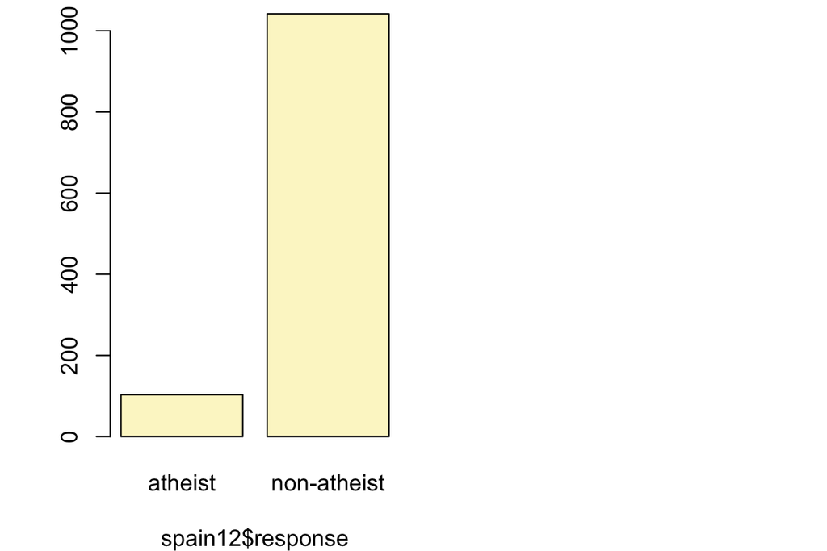

```
## p_hat = 0.09 ;  n = 1145
## Check conditions: number of successes = 103 ; number of failures = 1042
## Standard error = 0.0085
## 95 % Confidence interval = ( 0.0734 , 0.1065 )
```

```r
inference(spain05$response, est = "proportion", type = "ci", method="theoretical",suc="atheist")
```

```
## Single proportion -- success: atheist
## Summary statistics:
```

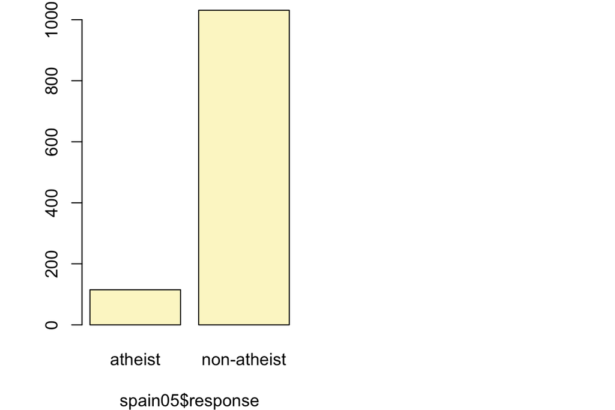

```
## p_hat = 0.1003 ;  n = 1146
## Check conditions: number of successes = 115 ; number of failures = 1031
## Standard error = 0.0089
## 95 % Confidence interval = ( 0.083 , 0.1177 )
```

```r
us12<-subset(atheism,nationality=="United States" & year=="2012")
head(us12)
```

```
##         nationality    response year
## 49926 United States non-atheist 2012
## 49927 United States non-atheist 2012
## 49928 United States non-atheist 2012
## 49929 United States non-atheist 2012
## 49930 United States non-atheist 2012
## 49931 United States non-atheist 2012
```

```r
us05<-subset(atheism,nationality=="United States" & year=="2005")
head(us05)
```

```
##         nationality    response year
## 67899 United States non-atheist 2005
## 67900 United States non-atheist 2005
## 67901 United States non-atheist 2005
## 67902 United States non-atheist 2005
## 67903 United States non-atheist 2005
## 67904 United States non-atheist 2005
```

```r
inference(us12$response, est = "proportion", type = "ci", method="theoretical",suc="atheist")
```

```
## Single proportion -- success: atheist
## Summary statistics:
```

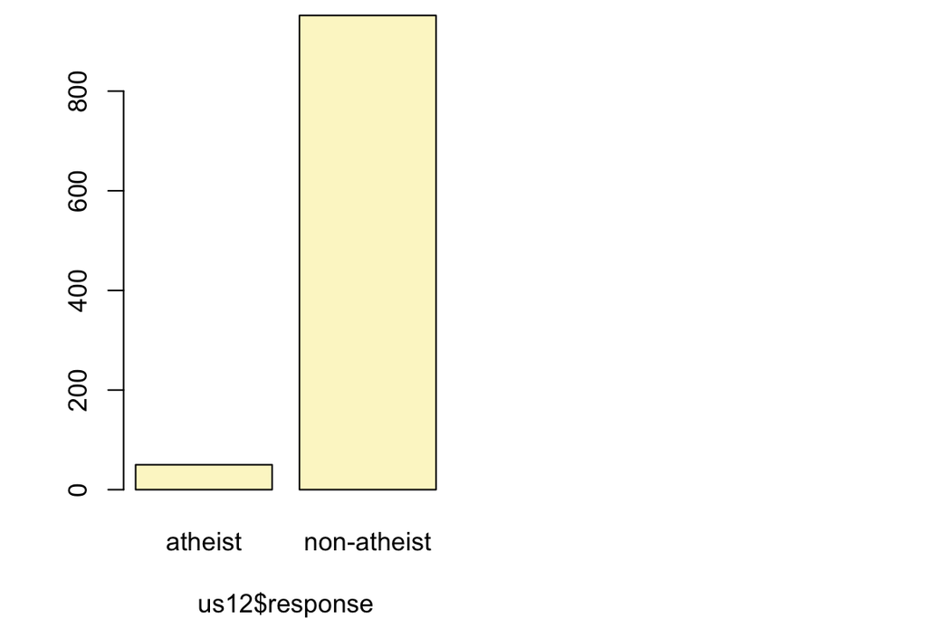

```
## p_hat = 0.0499 ;  n = 1002
## Check conditions: number of successes = 50 ; number of failures = 952
## Standard error = 0.0069
## 95 % Confidence interval = ( 0.0364 , 0.0634 )
```

```r
inference(us05$response, est = "proportion", type = "ci", method="theoretical",suc="atheist")
```

```
## Single proportion -- success: atheist
## Summary statistics:
```

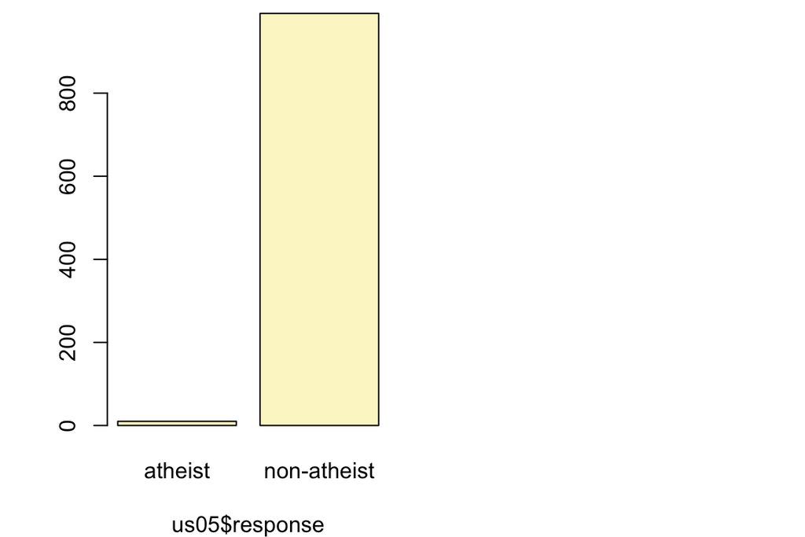

```
## p_hat = 0.01 ;  n = 1002
## Check conditions: number of successes = 10 ; number of failures = 992
## Standard error = 0.0031
## 95 % Confidence interval = ( 0.0038 , 0.0161 )
```

#### 2:

Since the margin of error is largest when p=0.5, we will use this to estimate.We then can manipulate the formula to set it equal to n, and therefore find the minimum number of people needed to survery to complete those requirements, which in this case is 9604.

```r
p=0.5
z=-1.96
ME=0.01
n=z^2*p*(1-p)/ME^2
n
```

```
## [1] 9604
```

#### 3:

The concepts of confidence intervals and inferences for categorical variables have been covered both in depth in class and in our textbook. It seems that we are following the textbook closely.